# LHX6

COBIND analysis report

Date: 2022-06-09

These are the results produced by the COBIND pipeline, which looks for sequence patterns in the neighbourhoods of the reference regions.

# Spacings summary

## Summary in a plot

Spacing summary plot describes the relationship between the anchor (in the center) and discovered co-binder motif (on the right). The squares show the spacing between the anchor and co-binder motifs that are displayed. The color of the square indicated the number of datasets this configuration is found in, while the the number inside indicates the proportion of input sequences this configuration was found in.

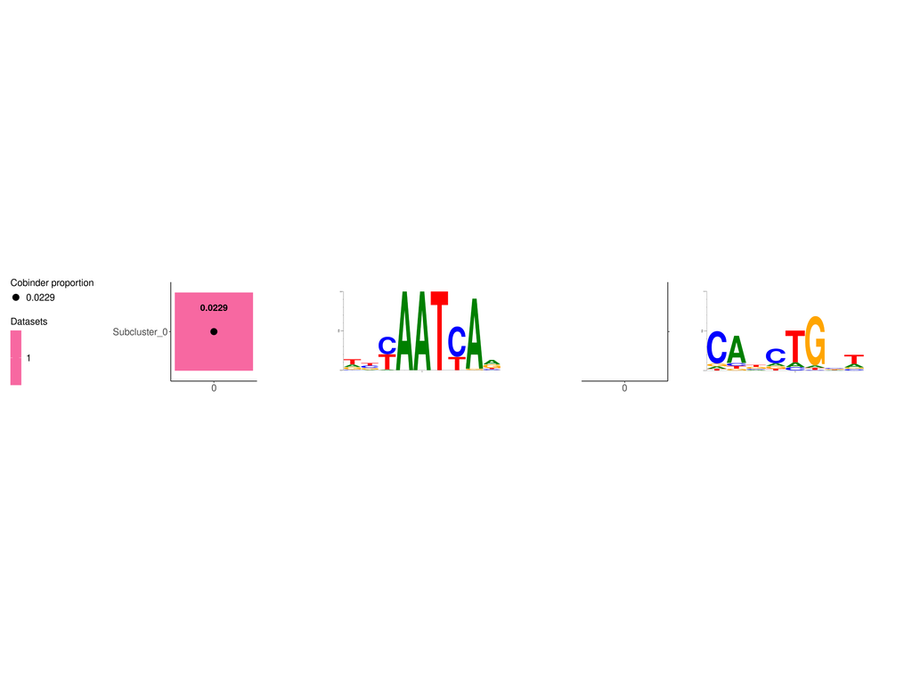

**Figure 1. Spacings summary plot**

# Co-binder validation through motif similarity and PPI data

To infer what transcription factor (TF) could be co-binding together with the anchor TF, we compare discovered co-binder motifs against the collection of know motifs (JASPAR and CIS-BP species-specific and pooled motif collections). Then, we search the protein-protein interaction data from STRING for these co-binder pairs. If such pair is found with significance, we confirm it as a validated anchor-co-binder pair (Figure 2). If the pair is not found in PPI data, we predict the TF based on motif similarity with know motifs (Figure 3).

## Co-binder matches in the PPI data

### cobinder_0

#### Species-specific motif library

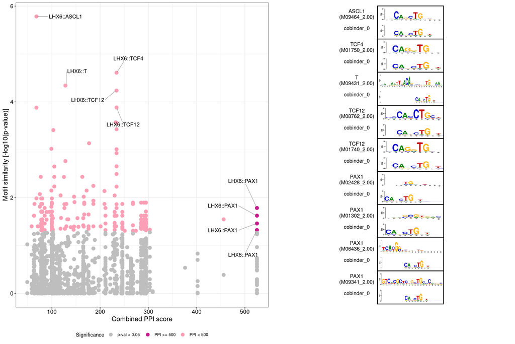

**Figure 2. Co-binder motif similarity with matches in protein-protein interactions (PPIs)**

## Co-binder motif similarity when no matches in the PPI data found

### cobinder_0

#### Species-specific motif library

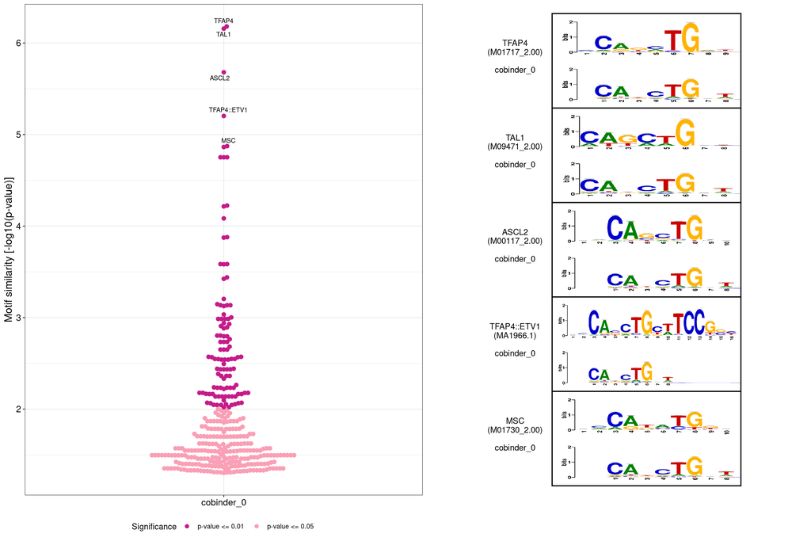

**Figure 3. Co-binder motif similarity when no matches in interactions (PPIs) were found for those motif pairs**

# Annotation of co-binder regions

Regions with and without co-binder are annotated using ChIPseeker package. *Co-binder only* are only co-binder regions extracted and annotated, while *Full* regions consists of anchors + flanks.

## Full

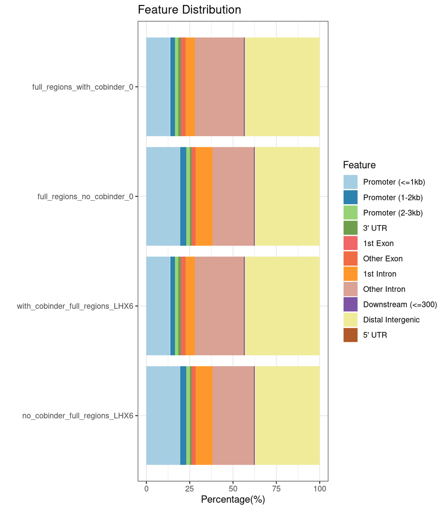

# Conservation of regions with and without co-binders

Conservation is analyzed for regions where co-binder was discovered relative to the anchor and also for the regions where none of the co-binders were not found. Chosen window to compute the conservation is 100 bp centering around the anchor motif.

## cobinder_0_left_0

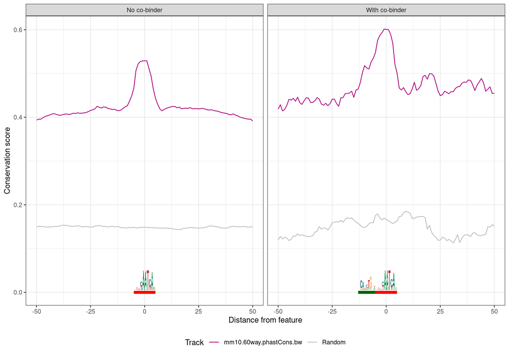

**Figure 5. Conservation of regions with and without co-binders.**